# R Notebook

07 January 2022 Explorations for the new year. Looking forward to an OSM virtual talk.

So far, we have some examples of species that are abundanter on big particles. And some size resolved eukaryotic eDNA stuff.

Things I’d like to at least try.

Some sort of CCA looking at the effects of particle size, latitude and depth on community structure, perhaps biplotting in some species.

How does alpha diversity vary as a function of size latitude and depth?

Something about gamma diversity. How do the diversity of different particle types affect overall alpha diversity in a volume of water?

## Notes from meeting with Louis plough about matt gray’s grant.

Doesn’t really belong here but this was open Louis AMOVA Diversity within regions, oceans rivers, ocean basins.

Expression profiels for host Fish for biomarker for host or microbial genes that precede a crash.

Or genes that are in.

If there is a bio signal of crashes we will see it.

```r
library(ggvegan)
library(vegan)
library(tidyverse)
source("InitialProcessing.R")
```

```
* `` -> ...1

* `` -> ...1




extract_numeric() is deprecated: please use readr::parse_number() instead
```

```r
source("ChesapeakePersonalLibrary.R")
```

```r
wideASVs <- nonSpikes20 %>%
  mutate(copiesPerLPermm = copiesPerL/Bin_Size) %>%
  #mutate(copiesPerLPermm = copiesPerL/MassperLiter) %>% # temporary swap out just to see
  select(ID, ASV, copiesPerLPermm) %>%
  pivot_wider(id_cols = ID, names_from = ASV, values_from = copiesPerLPermm) %>%
  column_to_rownames("ID") %>% na.omit()
```

```r
wideASVs_log <- log(wideASVs + 1)
wideASVs_scaled <- scale(wideASVs_log)
```

```r
library(vegan)
pcaTry2 <- rda(X = wideASVs_scaled)
```

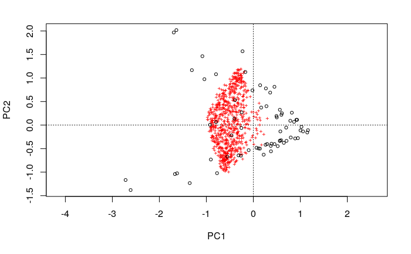

```r
plot(pcaTry2, scaling = 1)
```

Doesn’t work on scaled data the scaled data is negative. CCA only works with positive data. Therefore we skip the transformations.

```r
ccaTry2 <- cca(X = wideASVs_log)
```

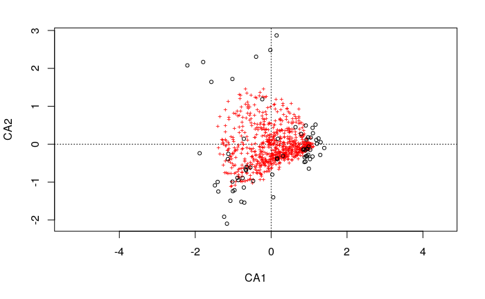

```r
plot(ccaTry2, scaling = 2)
```

```r
fortCCA <- fortify(ccaTry2, axes = 1:7)
sitesCCA <- fortCCA %>% filter(Score == "sites")
speciesCCA <- fortCCA %>% filter(Score == "species")
```

```r
ccabp <- function(){barplot(ccaTry2$CA$eig/ccaTry2$tot.chi)}
ggdraw(ccabp)
```

[output not shown]

```r
CAPctVarPlot <- enframe(ccaTry2$CA$eig/ccaTry2$tot.chi, name = "CA", value = "PctVarExplained") %>%
  mutate(CA = extract_numeric(CA)) %>%
  ggplot(aes(x = CA, y = PctVarExplained)) +
  geom_point() +
  geom_segment(aes(x = CA, xend = CA, y = 0, yend = PctVarExplained)) +
  labs(y = "Percent Variance Explained") +
  geom_vline(xintercept = 7.5, color = "grey") +
  theme_bw()
```

```
extract_numeric() is deprecated: please use readr::parse_number() instead
```

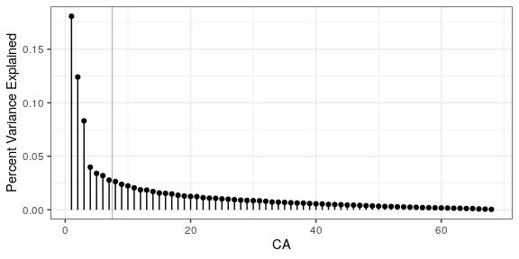

```r
CAPctVarPlot
```

Then lets left join some stuff on these

```r
sitesCCA_2 <- sitesCCA %>% left_join(microbialAbundance, by = c("Label" = "ID"))
```

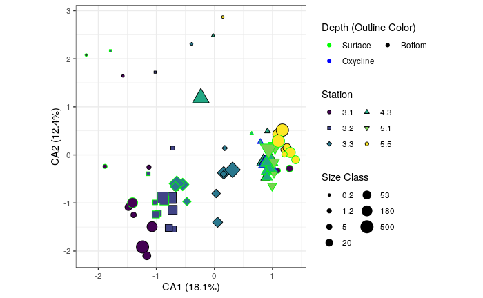

```r
myGuides <-   guides(shape = guide_legend(ncol = 2), fill = guide_legend(ncol = 2),
         size = guide_legend(ncol = 2),
         color = guide_legend(ncol = 2))

filterSizes <- c(0.2, 1.2, 5, 20, 53, 180, 500)
pCA1CA2_withlegend <- sitesCCA_2 %>%
  mutate(Depth = recode(Depth, `Oxy` = "Oxycline")) %>%
  select(Station, Depth, Size_Class, everything()) %>%
  ggplot(aes(x = CA1, y = CA2,
             fill = as.factor(Station),
             shape = as.factor(Station),
             size = sqrt(Size_Class),
             color = as.factor(Depth)
             )) +
  geom_point() +
  coord_fixed(sqrt(ccaTry2$CA$eig[2]/ccaTry2$CA$eig[1])) + # reshape to scale
  labs(x = paste0("CA1 (", round(ccaTry2$CA$eig[1]/ccaTry2$tot.chi, 3) * 100, "%)"),
       y = paste0("CA2 (", round(ccaTry2$CA$eig[2]/ccaTry2$tot.chi, 3) * 100, "%)"),
       col = "Depth (Outline Color)",
       fill = "Station",
       shape = "Station",
       size = "Size Class") +
  #coord_fixed(sqrt(1)) +
  scale_fill_viridis_d() +
  scale_shape_manual(values = rep(21:25, 2))+
  scale_color_manual(values = c("green", "blue", "black")) +
  scale_size(breaks = sqrt(filterSizes),
             labels = filterSizes) +
  theme_bw() +
  myGuides


pCA1CA2 <- pCA1CA2_withlegend + theme(legend.position = "none")
pCA_legend <- get_legend(pCA1CA2_withlegend)
pCA1CA2_withlegend
```

```r
pCA1CA3 <- sitesCCA_2 %>%
  ggplot(aes(x = CA1, y = CA3,
             fill = as.factor(Station),
             shape = as.factor(Station),
             size = sqrt(Size_Class),
             color = as.factor(Depth)
             )) +
  geom_point() +
  coord_fixed(sqrt(ccaTry2$CA$eig[3]/ccaTry2$CA$eig[1])) + # reshape to scale
  labs(x = paste0("CA1 (", round(ccaTry2$CA$eig[1]/ccaTry2$tot.chi, 3) * 100, "%)"),
       y = paste0("CA3 (", round(ccaTry2$CA$eig[3]/ccaTry2$tot.chi, 3) * 100, "%)")) +
  #coord_fixed(sqrt(.8)) +
  scale_fill_viridis_d() +
  scale_shape_manual(values = rep(21:25, 2))+
  scale_color_manual(values = c("green", "blue", "black")) +
  theme_bw() + theme(legend.position = "none")
```

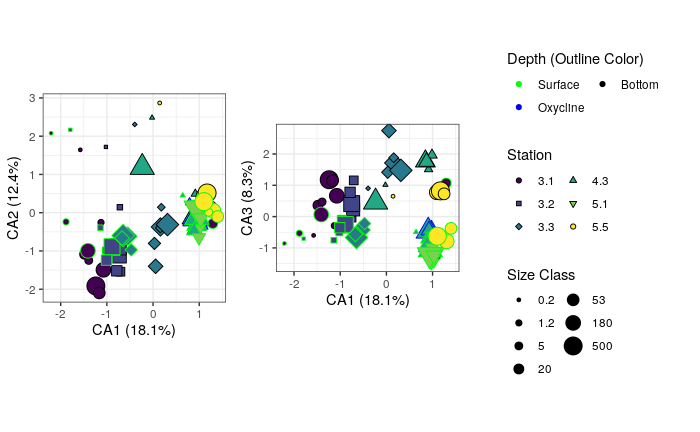

```r
cowplot::plot_grid(pCA1CA2, pCA1CA3, pCA_legend, nrow = 1)
```

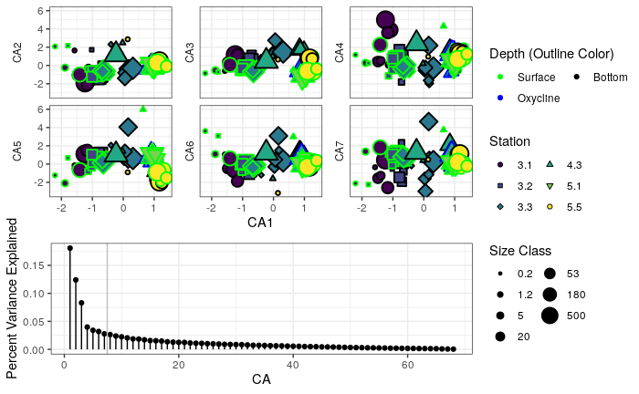

```r
allCAPlot <- sitesCCA_2 %>%
  select(Label, Station, Size_Class, Depth, CA1:CA7) %>%
  pivot_longer(CA2:CA7, names_to = "CA_ID", values_to = "CA_B") %>%
  ggplot(aes(x = CA1, y = CA_B,
             fill = as.factor(Station),
             shape = as.factor(Station),
             size = sqrt(Size_Class),
             color = as.factor(Depth)
             )) +
  geom_point(stroke = 1) +
  scale_fill_viridis_d() +
  scale_shape_manual(values = rep(21:25, 2))+
  scale_color_manual(values = c("green", "blue", "black")) +
  facet_wrap(~CA_ID,
             strip.position = "left") +
  ylab(NULL) +
  theme_bw() +
  theme(strip.background = element_blank(),
           strip.placement = "outside", legend.position = "none") +
  myGuides

plot_grid(
plot_grid(allCAPlot, CAPctVarPlot, nrow = 2, rel_heights = c(3, 2)),
pCA_legend, rel_widths = c(3,1)
)
```

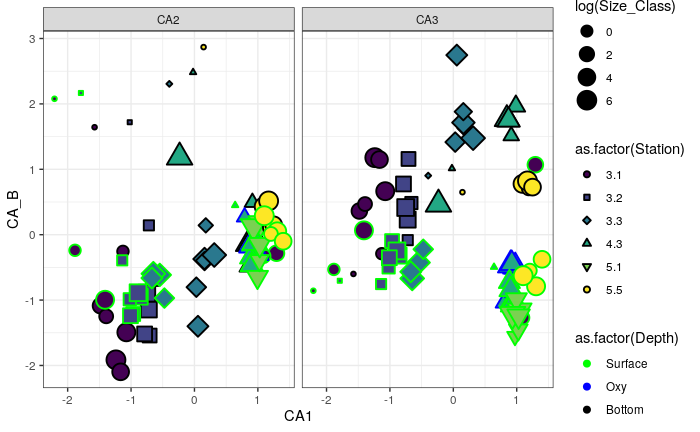

```r
sitesCCA_2 %>%
  select(Label, Station, Size_Class, Depth, CA1:CA3) %>%
  pivot_longer(CA2:CA3, names_to = "CA_ID", values_to = "CA_B") %>%
  ggplot(aes(x = CA1, y = CA_B,
             fill = as.factor(Station),
             shape = as.factor(Station),
             size = log(Size_Class),
             color = as.factor(Depth)
             )) +
  geom_point(stroke = 1) +
  scale_fill_viridis_d() +
  scale_shape_manual(values = rep(21:25, 2))+
  scale_color_manual(values = c("green", "blue", "black")) +
  facet_wrap(~CA_ID) +
  theme_bw()
```

So in general, there is a devide between stations (CA1 in order) free and not-free (CA2), and between surface and deep (CA3).

Less of a clean gradient along particle size overall, even as we get into the lower dimensions. I could fish for one to see if it exists with CCA, rather than just CA. But generally the size effects differ by stations. Different CA appear to partial out size effects for different stations.

# Constrained

```r
ccaConstrained <- cca(wideASVs_log ~ log(Size_Class), data = microbialAbundance)
```

```r
cca01 <- fortify(ccaConstrained, display = "wa") %>% left_join(microbialAbundance, by = c("Label" = "ID"))
```

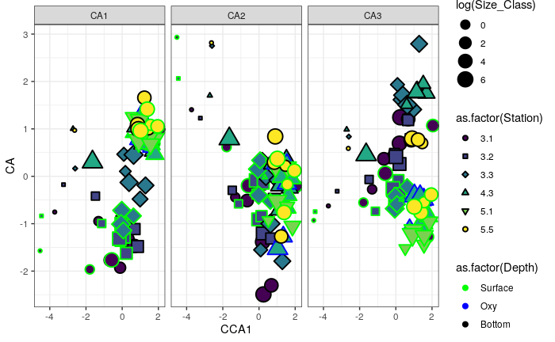

```r
cca01 %>%
  select(Label, Station, Size_Class, Depth, CCA1, CA1:CA3) %>%
  pivot_longer(CA1:CA3, names_to = "CA_ID", values_to = "CA") %>%
  ggplot(aes(x = CCA1, y = CA,
             fill = as.factor(Station),
             shape = as.factor(Station),
             size = log(Size_Class),
             color = as.factor(Depth)
             )) +
  geom_point(stroke = 1) +
  scale_fill_viridis_d() +
  scale_shape_manual(values = rep(21:25, 2))+
  scale_color_manual(values = c("green", "blue", "black")) +
  facet_wrap(~CA_ID) +
  theme_bw()
```

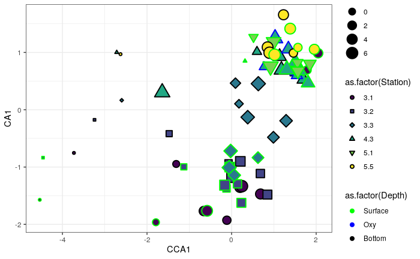

```r
cca01 %>%
  select(Label, Station, Size_Class, Depth, CCA1, CA1:CA3) %>%
  ggplot(aes(x = CCA1, y = CA1,
             fill = as.factor(Station),
             shape = as.factor(Station),
             size = log(Size_Class),
             color = as.factor(Depth)
             )) +
  geom_point(stroke = 1) +
  scale_fill_viridis_d() +
  scale_shape_manual(values = rep(21:25, 2))+
  scale_color_manual(values = c("green", "blue", "black")) +
  #facet_wrap(~CA_ID) +
  theme_bw()
```

## Constrained More vectors

```r
ccaConstrained <- cca(wideASVs_log ~ (Station)+ (Depth=="Surface") + sqrt(Size_Class), data = microbialAbundance)
```

```r
summary(ccaConstrained)
```

```
Call:
cca(formula = wideASVs_log ~ (Station) + (Depth == "Surface") +      sqrt(Size_Class), data = microbialAbundance)

Partitioning of scaled Chi-square:
              Inertia Proportion
Total          1.5562     1.0000
Constrained    0.2999     0.1927
Unconstrained  1.2563     0.8073

Eigenvalues, and their contribution to the scaled Chi-square

Importance of components:
                        CCA1    CCA2    CCA3    CA1     CA2     CA3     CA4     CA5     CA6     CA7     CA8     CA9
Eigenvalue            0.2145 0.05940 0.02606 0.1637 0.12828 0.09309 0.05764 0.04883 0.04294 0.03887 0.03738 0.03452
Proportion Explained  0.1378 0.03817 0.01675 0.1052 0.08243 0.05982 0.03704 0.03138 0.02759 0.02497 0.02402 0.02218
Cumulative Proportion 0.1378 0.17599 0.19274 0.2980 0.38040 0.44021 0.47725 0.50863 0.53622 0.56120 0.58522 0.60740
                         CA10    CA11    CA12    CA13    CA14    CA15    CA16    CA17    CA18    CA19    CA20    CA21
Eigenvalue            0.03357 0.02892 0.02840 0.02481 0.02409 0.02296 0.02111 0.02076 0.01984 0.01869 0.01816 0.01757
Proportion Explained  0.02157 0.01859 0.01825 0.01594 0.01548 0.01475 0.01357 0.01334 0.01275 0.01201 0.01167 0.01129
Cumulative Proportion 0.62897 0.64755 0.66580 0.68174 0.69723 0.71198 0.72554 0.73889 0.75164 0.76364 0.77531 0.78661
                         CA22    CA23    CA24     CA25     CA26     CA27     CA28     CA29     CA30     CA31     CA32
Eigenvalue            0.01725 0.01669 0.01557 0.015288 0.014622 0.014399 0.013339 0.013247 0.012965 0.011695 0.011154
Proportion Explained  0.01108 0.01073 0.01000 0.009824 0.009396 0.009253 0.008571 0.008512 0.008331 0.007515 0.007168
Cumulative Proportion 0.79769 0.80842 0.81842 0.828246 0.837642 0.846895 0.855466 0.863979 0.872310 0.879825 0.886992
                          CA33     CA34     CA35     CA36     CA37     CA38     CA39     CA40     CA41     CA42
Eigenvalue            0.011012 0.010662 0.010127 0.009529 0.009108 0.008758 0.007933 0.007756 0.007746 0.007058
Proportion Explained  0.007076 0.006851 0.006507 0.006123 0.005853 0.005628 0.005098 0.004984 0.004977 0.004536
Cumulative Proportion 0.894068 0.900919 0.907427 0.913550 0.919403 0.925030 0.930128 0.935112 0.940089 0.944625
                          CA43     CA44     CA45     CA46     CA47     CA48     CA49     CA50     CA51     CA52
Eigenvalue            0.006982 0.006642 0.006168 0.006004 0.005483 0.005209 0.004825 0.004521 0.004426 0.004192
Proportion Explained  0.004487 0.004268 0.003963 0.003858 0.003524 0.003347 0.003101 0.002905 0.002844 0.002693
Cumulative Proportion 0.949111 0.953379 0.957342 0.961200 0.964724 0.968071 0.971172 0.974077 0.976921 0.979614
                          CA53     CA54     CA55     CA56     CA57     CA58     CA59     CA60     CA61     CA62
Eigenvalue            0.003934 0.003736 0.003429 0.002986 0.002863 0.002711 0.002577 0.002493 0.002010 0.001889
Proportion Explained  0.002528 0.002401 0.002204 0.001919 0.001840 0.001742 0.001656 0.001602 0.001291 0.001214
Cumulative Proportion 0.982142 0.984543 0.986746 0.988665 0.990505 0.992247 0.993903 0.995505 0.996796 0.998010
                           CA63      CA64      CA65
Eigenvalue            0.0013691 0.0009966 0.0007307
Proportion Explained  0.0008797 0.0006404 0.0004695
Cumulative Proportion 0.9988901 0.9995305 1.0000000
```

[output cut: 324 more lines]

```
5-5-B-5    1.8341 -0.58146 -0.955683 -0.2001958  0.035129 -1.48422
5-5-B-500  2.0769  0.22705 -1.860473  0.6634840  0.108330 -1.85010
5-5-B-53   1.6623 -0.43104  1.864779 -0.6434562  0.778913 -1.80373
5-5-S-180  1.7109 -0.26934  1.683821 -0.4602398 -0.363646 -0.28742
5-5-S-5    1.8479  0.18662  1.173573 -0.1586221 -0.272955 -0.76486
5-5-S-500  2.0145  0.74131  0.552833  0.4693417 -0.412849 -0.67990
5-5-S-53   2.2573  1.54982 -0.351957  0.5125995 -0.327690 -1.20798


Biplot scores for constraining variables

                          CCA1    CCA2     CCA3 CA1 CA2 CA3
Station                 0.9744 -0.2135  0.07071   0   0   0
Depth == "Surface"TRUE -0.0505 -0.7379 -0.67297   0   0   0
sqrt(Size_Class)        0.3249  0.6915 -0.64520   0   0   0
```

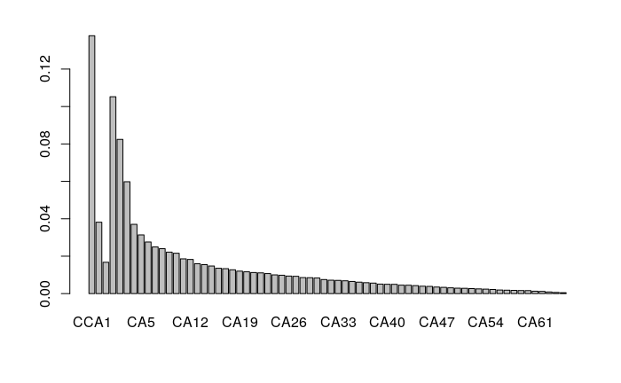

```r
barplot(
c(ccaConstrained$CCA$eig/ccaConstrained$tot.chi, ccaConstrained$CA$eig/ccaConstrained$tot.chi)
)
```

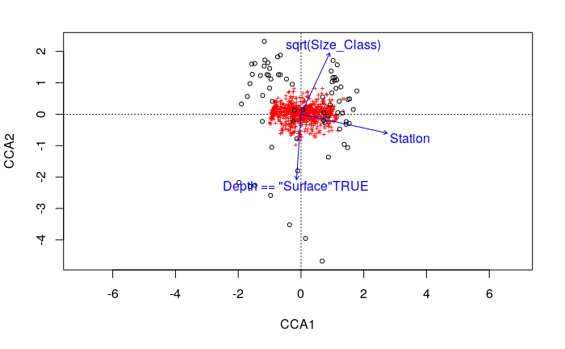

```r
plot(ccaConstrained)
```

```r
anova(ccaConstrained)
```

```
Permutation test for cca under reduced model
Permutation: free
Number of permutations: 999

Model: cca(formula = wideASVs_log ~ (Station) + (Depth == "Surface") + sqrt(Size_Class), data = microbialAbundance)
         Df ChiSquare      F Pr(>F)
Model     3   0.29995 5.1731  0.001 ***
Residual 65   1.25628
---
Signif. codes:  0 ‘***’ 0.001 ‘**’ 0.01 ‘*’ 0.05 ‘.’ 0.1 ‘ ’ 1
```

But what if everything is being driven by free vs attached. What if I throw out the free stuff and look for gradients ## Particles Only Is there a gradient effect for just the attached particles. Might start with just surface.

```r
partiKeep <- microbialAbundance$Size_Class > 2 & microbialAbundance$Depth == "Surface"
microbialAbundance_PK <- microbialAbundance[partiKeep,]
wideASVs_log_PK <- wideASVs_log[rownames(wideASVs_log) %in% microbialAbundance_PK$ID,]
```

```r
ccaConstrained_PK <- cca(wideASVs_log_PK ~ (Station) + log(Size_Class), data = microbialAbundance_PK)
```

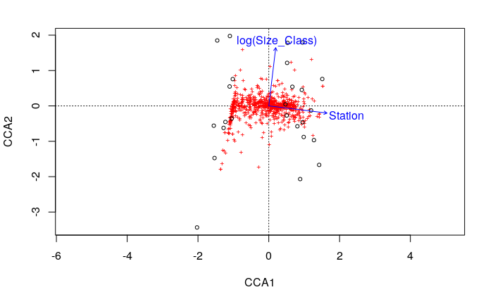

```r
plot(ccaConstrained_PK)
```

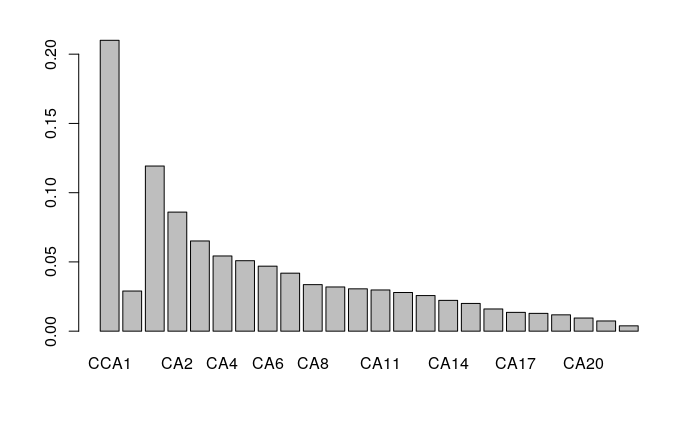

```r
barplot(
c(ccaConstrained_PK$CCA$eig/ccaConstrained_PK$tot.chi, ccaConstrained_PK$CA$eig/ccaConstrained_PK$tot.chi)
)
```

```r
anova(ccaConstrained_PK)
```

```
Permutation test for cca under reduced model
Permutation: free
Number of permutations: 999

Model: cca(formula = wideASVs_log_PK ~ (Station) + log(Size_Class), data = microbialAbundance_PK)
         Df ChiSquare      F Pr(>F)
Model     2   0.26894 3.4548  0.001 ***
Residual 22   0.85631
---
Signif. codes:  0 ‘***’ 0.001 ‘**’ 0.01 ‘*’ 0.05 ‘.’ 0.1 ‘ ’ 1
```

```r
ccaConstrained_PK_2 <- cca(wideASVs_log_PK ~ Condition(as.factor(Station)) + log(Size_Class), data = microbialAbundance_PK)
```

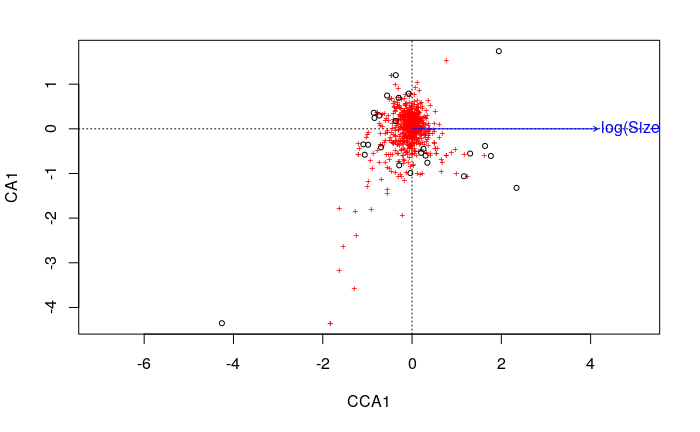

```r
plot(ccaConstrained_PK_2)
```

```r
anova(ccaConstrained_PK_2)
```

```
Permutation test for cca under reduced model
Permutation: free
Number of permutations: 999

Model: cca(formula = wideASVs_log_PK ~ Condition(as.factor(Station)) + log(Size_Class), data = microbialAbundance_PK)
         Df ChiSquare      F Pr(>F)
Model     1   0.03249 1.0357  0.404
Residual 18   0.56463
```

Wait! No its not. At least with the 5 and bigger only in the surface, conditioned. 1.2 and bigger there is a size effect. I need to automate this question and show this cutoff. This says, to me that the 5 micron and larger particles are more or less indistinguishable from eachother. Currently I’ve done this for the cells/L but not cells/mg particle, might be different in the later case, which I should check. Just checked, no better. Huh. Very interesting. Not what I expected. I expected that there would be some smooth gradient with respect to size. Maybe there is a bunch of aggregation and disaggregation happening?

```r
summary(ccaConstrained_PK_2)
```

```
Call:
cca(formula = wideASVs_log_PK ~ Condition(as.factor(Station)) +      log(Size_Class), data = microbialAbundance_PK)

Partitioning of scaled Chi-square:
              Inertia Proportion
Total         1.12525    1.00000
Conditioned   0.52812    0.46934
Constrained   0.03249    0.02887
Unconstrained 0.56463    0.50179

Eigenvalues, and their contribution to the scaled Chi-square
after removing the contribution of conditiniong variables

Importance of components:
                         CCA1     CA1     CA2     CA3     CA4     CA5    CA6     CA7     CA8     CA9    CA10
Eigenvalue            0.03249 0.07741 0.05540 0.05199 0.04951 0.04484 0.0384 0.03603 0.03573 0.03044 0.02586
Proportion Explained  0.05441 0.12965 0.09277 0.08706 0.08292 0.07510 0.0643 0.06034 0.05983 0.05097 0.04331
Cumulative Proportion 0.05441 0.18405 0.27683 0.36389 0.44681 0.52191 0.5862 0.64655 0.70638 0.75736 0.80067
                         CA11    CA12    CA13    CA14    CA15    CA16     CA17     CA18
Eigenvalue            0.02462 0.02079 0.01731 0.01521 0.01392 0.01313 0.009712 0.004351
Proportion Explained  0.04123 0.03481 0.02898 0.02547 0.02331 0.02198 0.016264 0.007287
Cumulative Proportion 0.84190 0.87671 0.90569 0.93116 0.95447 0.97645 0.992713 1.000000

Accumulated constrained eigenvalues
Importance of components:
                         CCA1
Eigenvalue            0.03249
Proportion Explained  1.00000
Cumulative Proportion 1.00000

Scaling 2 for species and site scores
* Species are scaled proportional to eigenvalues
* Sites are unscaled: weighted dispersion equal on all dimensions


Species scores

              CCA1       CA1        CA2        CA3        CA4        CA5
ASV_2     0.021122 -0.133440 -8.957e-02  0.1877733  3.553e-02 -0.0298290
ASV_3     0.029834 -0.040724  1.310e-01  0.0565561  8.781e-02 -0.0312900
```

[output cut: 216 more lines]

```
5-1-S-180 -1.83864 -0.3482  1.41871  1.48111 -0.7384  1.2113
5-1-S-20  -0.78201  0.2976 -1.71063 -0.37343 -1.3322 -0.6997
5-1-S-5   -0.03921  0.6942 -0.99813 -1.17140  2.5885  0.1258
5-1-S-500  0.89271 -0.7586  1.62952  1.32724 -0.5956  0.0468
5-1-S-53   1.67141 -0.6072  0.94417  0.17661 -1.9001 -0.5726
5-5-S-180 -1.95146  0.2436 -0.76055  2.89157  1.0690 -2.0586
5-5-S-5   -0.15203  0.1767  0.42492 -1.19746 -0.3492  1.2752
5-5-S-500  0.77989 -0.6008  1.06021  1.05570  0.6507 -0.2185
5-5-S-53   1.55859 -0.3830 -1.35453  0.79159 -0.1551 -2.2001


Biplot scores for constraining variables

                  CCA1 CA1 CA2 CA3 CA4 CA5
log(Size_Class) 0.9796   0   0   0   0   0
```

```r
ccaPK <- fortify(ccaConstrained_PK_2, display = "wa") %>% left_join(microbialAbundance, by = c("Label" = "ID"))
```

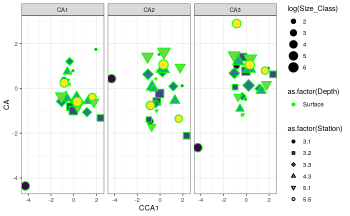

```r
ccaPK %>%
  select(Label, Station, Size_Class, Depth, CCA1, CA1:CA3) %>%
  pivot_longer(CA1:CA3, names_to = "CA_ID", values_to = "CA") %>%
  ggplot(aes(x = CCA1, y = CA,
             fill = as.factor(Station),
             shape = as.factor(Station),
             size = log(Size_Class),
             color = as.factor(Depth)
             )) +
  geom_point(stroke = 1) +
  scale_fill_viridis_d() +
  scale_shape_manual(values = rep(21:25, 2))+
  scale_color_manual(values = c("green", "blue", "black")) +
  facet_wrap(~CA_ID) +
  theme_bw()
```

## Conditioned size dependence, this time in terms of size per mg particle.

Results are the same, with changes to the code above.

Now to DRY code this so that the results all show up in a meaningful way.